# IMDb Review Classification

DSST389: Advanced Data Science

Author

Affiliation

*Amaree Walker & Cooper Woods*

University of Richmond

Published

April 16, 2025

## Introduction

IMDb reviews often express strong opinions about films, making them a valuable resource for sentiment analysis. In this project, we classify review sentiment—positive or negative—using two approaches: one based on tf-idf and another using word embeddings.

We compare model performance to determine which method better captures sentiment patterns in movie reviews, using a labeled dataset and techniques from the Text classification with models notebook.

### Library Setup

Below we will import the necessary libraries and packages for our analysis.

```r
library(tidyverse) # Data manipulation, visualization, and analysis
library(ggrepel) # Improved readability of labels
library(dplyr) # Efficient data manipulation
library(stringr) # Character string manipulation
theme_set(theme_minimal()) # Minimalistic theme for the plots

packages <- c(
  "tidyverse", "tidymodels", "textrecipes", "kknn",
  "xgboost", "glmnet", "corrplot", "parallel", "future",
  "textdata", "glue", "stats"
)

for (pkg in packages) {
  library(pkg, character.only = TRUE)
}

theme_set(theme_minimal())

set.seed(123)

all_cores <- parallel::detectCores()
plan(multisession, workers = all_cores)
```

## About the Data

This data was collected from Stanford’s [Large Movie Review Dataset](https://ai.stanford.edu/~amaas/data/sentiment/?utm_source=chatgpt.com), which is a collection of texts from 50,000 IMDb reviews. Scores of 1-4 were categorized to be negative sentiment, while scores of 7-10 were categorized to be positive sentiment. Neutral scores of 5 and 6 were removed from the dataset.

We begin by loading the dataset. Here are the first few rows of `reviews``:

```
# A tibble: 4 × 5
# Groups:   sentiment [2]
     id rating sentiment split text
  <dbl>  <dbl> <chr>     <chr> <chr>
1 31347      4 neg       train "\"True\" story of three girls who go into the w…
2 31395      2 neg       train "Memoirs of a Geisha is a beautifully filmed mov…
3 15486      8 pos       test  "The Man with the Golden Arm was one of the firs…
4 14342      8 pos       test  "I read the book before seeing the movie, and th…
```

### Data Dictionary

The IMDb dataset used in this analysis contains the following variables:

- **text**: The full written movie review. This is the primary predictor variable.
- **sentiment**: The label indicating whether the review is positive or negative. This is the target variable used for classification.

Additional variables created during preprocessing include:

- **.pred_class**: The predicted class label from the model (positive/negative).
- **.pred_positive** and **.pred_negative**: Model-assigned probabilities for each sentiment class.
- **correct**: A logical value indicating whether the model’s prediction matches the true label (used for evaluation and plotting).

### Cleaning the data

In order to clean the data, we first convert the `sentiment` column to an indicator variable such that `"neg" == 0` and `"positive" == 1`. Then, we ensure that `sentiment` is a saved as a factor.

```
# A tibble: 50,000 × 5
      id rating sentiment split text
   <dbl>  <dbl> <fct>     <chr> <chr>
 1     1      2 0         test  "Once again Mr. Costner has dragged out a movie…
 2     2      4 0         test  "This is an example of why the majority of acti…
 3     3      1 0         test  "First of all I hate those moronic rappers, who…
 4     4      3 0         test  "Not even the Beatles could write songs everyon…
 5     5      3 0         test  "Brass pictures (movies is not a fitting word f…
 6     6      2 0         test  "A funny thing happened to me while watching \"…
 7     7      2 0         test  "This German horror film has to be one of the w…
 8     8      2 0         test  "Being a long-time fan of Japanese film, I expe…
 9     9      4 0         test  "\"Tokyo Eyes\" tells of a 17 year old Japanese…
10    10      4 0         test  "Wealthy horse ranchers in Buenos Aires have a …
# ℹ 49,990 more rows
```

### Exploratory analysis

We conduct some exploratory analysis to see how our data initially presents. Are there any obvious patterns?

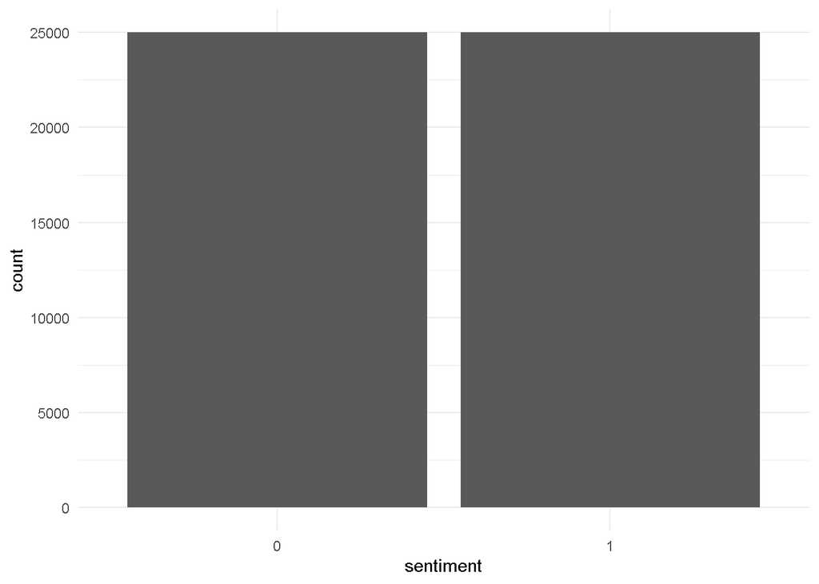

### Splitting the data

Next, we split your data into training and testing sets (80%-20%), stratified by the sentiment type (pos or neg), and output our splits.

```
<Training/Testing/Total>
<40000/10000/50000>
```

## Analysis 1: tf-idf Model

### Recipe

To begin our first analysis, we first create a recipe that tokenizes the text, removes stopwords, converts counts into term frequencies, and filters for the top 100 tokens. Then we output our recipe.

```
── Recipe ──────────────────────────────────────────────────────────────────────
```

```
── Inputs
```

```
Number of variables by role
```

```
outcome:   1
predictor: 1
```

```
── Operations
```

```
• Tokenization for: text
```

```
• Stop word removal for: text
```

```
• Text filtering for: text
```

```
• Term frequency-inverse document frequency with: text
```

### Model Specification

Then, we specify a logistic regression model for classification using glm and output our model specification.

```
Logistic Regression Model Specification (classification)

Computational engine: glm
```

### Workflow and Fitting

Next we create a workflow, fit the logistic regression model to our training data, and return the fit model for our reviews.

```
══ Workflow [trained] ══════════════════════════════════════════════════════════
Preprocessor: Recipe
Model: logistic_reg()

── Preprocessor ────────────────────────────────────────────────────────────────
4 Recipe Steps

• step_tokenize()
• step_stopwords()
• step_tokenfilter()
• step_tfidf()

── Model ───────────────────────────────────────────────────────────────────────

Call:  stats::glm(formula = ..y ~ ., family = stats::binomial, data = data)

Coefficients:
          (Intercept)          tfidf_text_10      tfidf_text_acting
              1.09861                1.00137               -4.80349
    tfidf_text_action      tfidf_text_actors    tfidf_text_actually
              0.26048               -2.35969               -3.24587
      tfidf_text_also     tfidf_text_another      tfidf_text_around
              3.61768               -1.71100               -1.78963
      tfidf_text_back         tfidf_text_bad        tfidf_text_best
              0.14090              -14.13083                6.00620
    tfidf_text_better         tfidf_text_big          tfidf_text_br
             -4.14130               -0.55208               -1.60656
       tfidf_text_can        tfidf_text_cast   tfidf_text_character
              0.45078                0.19013               -0.96466
tfidf_text_characters      tfidf_text_comedy    tfidf_text_director
             -1.00014               -0.01270               -2.70080
       tfidf_text_end      tfidf_text_enough        tfidf_text_even
             -0.66520               -2.97183               -6.64637
      tfidf_text_ever       tfidf_text_every        tfidf_text_fact
             -2.53820                0.13873               -1.40990
      tfidf_text_film       tfidf_text_films        tfidf_text_find
             -0.34092                0.68794                1.37483
     tfidf_text_first       tfidf_text_funny         tfidf_text_get
              0.62364                0.16538               -1.57757
      tfidf_text_give          tfidf_text_go       tfidf_text_going
```

[output cut: 11 more lines]

```
      tfidf_text_make       tfidf_text_makes         tfidf_text_man
             -4.28144                2.77831                0.52094
      tfidf_text_many         tfidf_text_may       tfidf_text_movie
              1.15098                1.41936               -2.50080
    tfidf_text_movies        tfidf_text_much       tfidf_text_never
             -0.30248               -1.64076               -0.78104
       tfidf_text_new     tfidf_text_nothing         tfidf_text_now
              1.31778               -8.93807                0.48663
       tfidf_text_old         tfidf_text_one        tfidf_text_part
             -1.07622               -0.63653               -0.54840
    tfidf_text_people        tfidf_text_plot      tfidf_text_pretty
             -1.08643               -5.22951               -3.57415

...
and 26 more lines.
```

### Predictions and Evaluation

Finally, we can evaluate our fit model by predicting on our test data. We bind both the probabilities, predicted classes, and original columns of the test data to the results object, and retrieve a confusion matrix (`conf_mat()`) from the results. Also, we use the results to calculate the `accuracy()` of our model.

```
          Truth
Prediction    0    1
         0 3645 1287
         1 1355 3713
```

```r
reviews_results |> accuracy(truth = sentiment, estimate = .pred_class)
```

```
# A tibble: 1 × 3
  .metric  .estimator .estimate
  <chr>    <chr>          <dbl>
1 accuracy binary         0.736
```

### Visualization

Now, we want to create a visualization showing how well our model is performing:

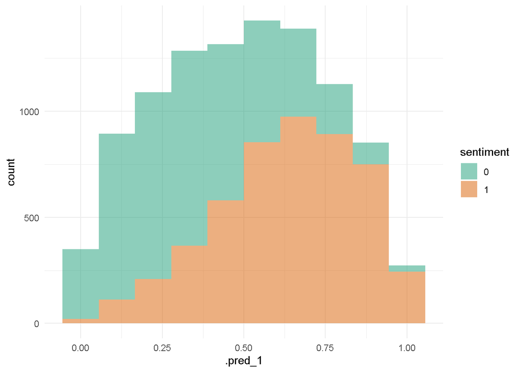

```r
reviews_results |>
  ggplot(aes(x = .pred_1, fill = sentiment)) +
  geom_histogram(alpha = 0.5, bins = 10) +
  scale_fill_brewer(palette = "Dark2")
```

This model is performing well but not great. In general, our model is only about 24% more accurate than chance at predicting which reviews are positive or negative, which is why we see more of a normal distribution visualization as opposed to seeing a U-shaped curve graph.

### Interpretation

What does this all mean? Let’s find out which words our tf-idf model most associates with positive reviews. Below, we extract the twenty terms from the model that are most strongly associated with positive reviews.

```r
reviews_fit |>
  tidy() |>
  slice_max(estimate, n = 20)
```

```
# A tibble: 20 × 5
   term             estimate std.error statistic  p.value
   <chr>               <dbl>     <dbl>     <dbl>    <dbl>
 1 tfidf_text_great     9.91     0.788     12.6  2.98e-36
 2 tfidf_text_best      6.01     0.716      8.39 4.80e-17
 3 tfidf_text_love      4.97     0.681      7.30 2.78e-13
 4 tfidf_text_well      4.93     0.845      5.83 5.59e- 9
 5 tfidf_text_also      3.62     0.794      4.56 5.22e- 6
 6 tfidf_text_still     3.24     0.687      4.72 2.33e- 6
 7 tfidf_text_makes     2.78     0.654      4.25 2.17e- 5
 8 tfidf_text_years     2.67     0.650      4.11 3.91e- 5
 9 tfidf_text_world     2.65     0.592      4.48 7.42e- 6
10 tfidf_text_life      2.53     0.681      3.71 2.05e- 4
11 tfidf_text_see       2.49     0.873      2.85 4.33e- 3
12 tfidf_text_quite     2.20     0.614      3.59 3.34e- 4
13 tfidf_text_good      1.99     0.934      2.13 3.35e- 2
14 tfidf_text_young     1.43     0.576      2.49 1.29e- 2
15 tfidf_text_may       1.42     0.602      2.36 1.84e- 2
16 tfidf_text_lot       1.39     0.637      2.18 2.94e- 2
17 tfidf_text_find      1.37     0.635      2.17 3.03e- 2
18 tfidf_text_new       1.32     0.607      2.17 3.01e- 2
19 tfidf_text_us        1.19     0.592      2.01 4.49e- 2
20 tfidf_text_many      1.15     0.722      1.59 1.11e- 1
```

Now, let’s see which words does our tf-idf model most associates with negative review.

```r
reviews_fit |>
  tidy() |>
  slice_min(estimate, n = 20)
```

```
# A tibble: 20 × 5
   term                 estimate std.error statistic  p.value
   <chr>                   <dbl>     <dbl>     <dbl>    <dbl>
 1 tfidf_text_bad         -14.1      0.788    -17.9  5.74e-72
 2 tfidf_text_nothing      -8.94     0.667    -13.4  6.65e-41
 3 tfidf_text_even         -6.65     0.892     -7.45 9.13e-14
 4 tfidf_text_thing        -5.50     0.670     -8.21 2.23e-16
 5 tfidf_text_just         -5.29     0.989     -5.35 8.90e- 8
 6 tfidf_text_plot         -5.23     0.715     -7.31 2.64e-13
 7 tfidf_text_acting       -4.80     0.738     -6.51 7.46e-11
 8 tfidf_text_make         -4.28     0.784     -5.46 4.82e- 8
 9 tfidf_text_better       -4.14     0.699     -5.92 3.13e- 9
10 tfidf_text_pretty       -3.57     0.611     -5.85 4.81e- 9
11 tfidf_text_seems        -3.40     0.628     -5.42 5.84e- 8
12 tfidf_text_actually     -3.25     0.656     -4.95 7.57e- 7
13 tfidf_text_enough       -2.97     0.619     -4.80 1.56e- 6
14 tfidf_text_like         -2.92     1.05      -2.79 5.28e- 3
15 tfidf_text_made         -2.73     0.780     -3.51 4.53e- 4
16 tfidf_text_director     -2.70     0.634     -4.26 2.06e- 5
17 tfidf_text_something    -2.63     0.687     -3.83 1.29e- 4
18 tfidf_text_ever         -2.54     0.706     -3.59 3.27e- 4
19 tfidf_text_movie        -2.50     1.20      -2.08 3.75e- 2
20 tfidf_text_watching     -2.43     0.655     -3.71 2.11e- 4
```

Overall, some of the word associations make sense intuitively (like good being more associated with positive reviews) while others (like pretty being more associated with negative reviews) not so much. Let’s see if our second model can do any better.

## Analysis 2: Word Vector-Based Logistic Regression

In this analysis, we apply word embeddings rather than token frequencies to represent the text data. Word embeddings map each word into a numeric vector space that captures semantic meaning.

### Download and Load GloVe Embeddings

We begin by downloading 300-dimensional GloVe embeddings using the textdata package

```r
options(timeout = 1000)

glove <- textdata::embedding_glove6b(dim = 300)

glove |> slice_sample(n = 5) # preview sample of the embeddings
```

```
# A tibble: 5 × 301
  token        d1       d2       d3       d4     d5     d6      d7       d8
  <chr>     <dbl>    <dbl>    <dbl>    <dbl>  <dbl>  <dbl>   <dbl>    <dbl>
1 mossy   -0.892   0.00285  0.00190  0.141   -0.258 -0.106  0.476  -0.221
2 tantei   0.0300 -1.04    -0.236   -0.0893  -0.153 -0.505 -0.0102 -0.669
3 cavern  -0.464   0.502   -0.189   -0.00785  0.170 -0.106  0.280  -0.00577
4 daoud   -0.0234 -0.167    0.550    0.119   -0.146 -0.369 -0.779   0.538
5 botulin  0.153   0.0813  -0.116    0.0769  -0.417  0.894  0.189  -0.137
# ℹ 292 more variables: d9 <dbl>, d10 <dbl>, d11 <dbl>, d12 <dbl>, d13 <dbl>,
#   d14 <dbl>, d15 <dbl>, d16 <dbl>, d17 <dbl>, d18 <dbl>, d19 <dbl>,
#   d20 <dbl>, d21 <dbl>, d22 <dbl>, d23 <dbl>, d24 <dbl>, d25 <dbl>,
#   d26 <dbl>, d27 <dbl>, d28 <dbl>, d29 <dbl>, d30 <dbl>, d31 <dbl>,
#   d32 <dbl>, d33 <dbl>, d34 <dbl>, d35 <dbl>, d36 <dbl>, d37 <dbl>,
#   d38 <dbl>, d39 <dbl>, d40 <dbl>, d41 <dbl>, d42 <dbl>, d43 <dbl>,
#   d44 <dbl>, d45 <dbl>, d46 <dbl>, d47 <dbl>, d48 <dbl>, d49 <dbl>, …
```

### Define Logistic Regression Model

We specify a logistic regression model with L1 regularization (lasso). The penalty parameter will be tuned.

```r
log_spec <- logistic_reg(penalty = tune(), mixture = 1) |>
  set_engine("glmnet") |>
  set_mode("classification")
```

### Create Recipe and Workflow

We build a recipe that tokenizes text, removes stop words, and replaces tokens with word embeddings. Then, we combine this with our model in a workflow.

```r
embedding_recipe <- recipe(sentiment ~ text, data = train_data) |>
  step_tokenize(text) |>
  step_stopwords(text) |>
  step_word_embeddings(text, embeddings = glove)

embedding_wf <- workflow() |>
  add_recipe(embedding_recipe) |>
  add_model(log_spec)
```

### Cross-Validation Setup

We use 5-fold cross-validation to tune the penalty hyperparameter. Stratification ensures that each fold has a balanced sentiment distribution.

```r
embedding_folds <- vfold_cv(train_data, v = 5, strata = sentiment)
```

### Hyperparameter Tuning

```r
plan(sequential)
# Explained in sources section at the end

embedding_grid <- grid_regular(penalty(), levels = 5)

embedding_tune <- tune_grid(
  embedding_wf,
  resamples = embedding_folds,
  grid = embedding_grid,
  metrics = metric_set(accuracy)
)
embedding_best <- select_best(embedding_tune, metric = "accuracy")

embedding_final_wf <- finalize_workflow(embedding_wf, embedding_best)
```

[output not shown]

### Final Fit on Test Data

We now evaluate the finalized model using the test set created earlier. We report both the confusion matrix and accuracy.

```r
embedding_final_fit <- embedding_final_wf |> last_fit(split = data_split)

embedding_results <- collect_predictions(embedding_final_fit)

embedding_results |> conf_mat(truth = sentiment, estimate = .pred_class)
```

```
          Truth
Prediction    0    1
         0 4172  848
         1  828 4152
```

```r
embedding_results |> accuracy(truth = sentiment, estimate = .pred_class)
```

```
# A tibble: 1 × 3
  .metric  .estimator .estimate
  <chr>    <chr>          <dbl>
1 accuracy binary         0.832
```

### Interpretation

```r
embedding_final_fit |>
  extract_fit_parsnip() |>
  tidy() |>
  slice_max(estimate, n = 20)
```

```
# A tibble: 20 × 3
   term                estimate      penalty
   <chr>                  <dbl>        <dbl>
 1 wordembed_text_d244   0.0859 0.0000000001
 2 wordembed_text_d139   0.0844 0.0000000001
 3 wordembed_text_d150   0.0792 0.0000000001
 4 wordembed_text_d55    0.0703 0.0000000001
 5 wordembed_text_d256   0.0633 0.0000000001
 6 wordembed_text_d167   0.0610 0.0000000001
 7 wordembed_text_d132   0.0563 0.0000000001
 8 wordembed_text_d183   0.0502 0.0000000001
 9 wordembed_text_d175   0.0495 0.0000000001
10 wordembed_text_d22    0.0490 0.0000000001
11 wordembed_text_d127   0.0487 0.0000000001
12 wordembed_text_d234   0.0479 0.0000000001
13 wordembed_text_d62    0.0469 0.0000000001
14 wordembed_text_d68    0.0467 0.0000000001
15 wordembed_text_d61    0.0436 0.0000000001
16 wordembed_text_d113   0.0420 0.0000000001
17 wordembed_text_d111   0.0418 0.0000000001
18 wordembed_text_d105   0.0403 0.0000000001
19 wordembed_text_d11    0.0402 0.0000000001
20 wordembed_text_d233   0.0395 0.0000000001
```

```r
embedding_final_fit |>
  extract_fit_parsnip() |>
  tidy() |>
  slice_min(estimate, n = 20)
```

```
# A tibble: 20 × 3
   term                estimate      penalty
   <chr>                  <dbl>        <dbl>
 1 wordembed_text_d27   -0.0985 0.0000000001
 2 wordembed_text_d9    -0.0822 0.0000000001
 3 wordembed_text_d192  -0.0741 0.0000000001
 4 wordembed_text_d291  -0.0732 0.0000000001
 5 wordembed_text_d207  -0.0667 0.0000000001
 6 wordembed_text_d125  -0.0634 0.0000000001
 7 wordembed_text_d290  -0.0620 0.0000000001
 8 wordembed_text_d239  -0.0608 0.0000000001
 9 wordembed_text_d95   -0.0554 0.0000000001
10 wordembed_text_d166  -0.0551 0.0000000001
11 wordembed_text_d148  -0.0533 0.0000000001
12 wordembed_text_d80   -0.0523 0.0000000001
13 wordembed_text_d29   -0.0522 0.0000000001
14 wordembed_text_d168  -0.0520 0.0000000001
15 wordembed_text_d119  -0.0517 0.0000000001
16 wordembed_text_d267  -0.0474 0.0000000001
17 wordembed_text_d231  -0.0472 0.0000000001
18 wordembed_text_d78   -0.0468 0.0000000001
19 wordembed_text_d147  -0.0464 0.0000000001
20 wordembed_text_d195  -0.0453 0.0000000001
```

## T-Test: Comparing Model Accuracy

We use a paired t-test to compare prediction correctness between the tf-idf model and the embedding model.

```r
token_correct <- reviews_results |> pull(.pred_class) ==
  reviews_results |> pull(sentiment)
embed_correct <- embedding_results |> pull(.pred_class) ==
  embedding_results |> pull(sentiment)

token_correct |> t.test(embed_correct, paired = TRUE)
```

```
    Paired t-test

data:  token_correct and embed_correct
t = -19.512, df = 9999, p-value < 2.2e-16
alternative hypothesis: true mean difference is not equal to 0
95 percent confidence interval:
 -0.10630434 -0.08689566
sample estimates:
mean difference
        -0.0966
```

## Conclusion

From a practical perspective, **tf-idf may be preferable when training data is plentiful and well-labeled**, while **word embeddings offer advantages in scenarios with smaller datasets or where semantic similarity is more important than exact word usage.**